# R data challenge

Michael Škvrňák

May 30, 2016

# Zadání

Cíl – použij Rko a:

- objev klíčové ukazatele (ne)spokojenosti zaměstnanců a / nebo
- identifikuj pravidla, korelace, nebo otázky rozdělující zaměstnance a / nebo
- vytvoř atraktivní vizualizace plné informací

## Otázky

- Q01: Můj nadřízený jasně hodnotí plnění úkolů a cílů
- Q02: Můj nadřízený dobře stanovuje cíle a priority
- Q03: Můj nadřízený se umí rychle a správně rozhodnout
- Q04: Můj nadřízený podporuje spolupráci v týmu a vytváří pro ni dobré podmínky
- Q05: Důvěřuji rozhodnutím, která učinil můj nadřízený
- Q06: Můj nadřízený umí ocenit můj výkon
- Q07: Můj nadřízený se zajímá o naše názory a nápady a bere na ně ohled
- Q08: Domnívám se, že můj nadřízený jedná se zaměstnanci spravedlivě
- Q09: Můj nadřízený má dostatečnou autoritu a je respektován všemi členy týmu
- Q10: Můj nadřízený mě vede ke zlepšení mého pracovního výkonu
- Q11: Můj nadřízený aktivně podporuje můj odborný růst
- Q12: Mé oddělení/tým pracuje efektivně
- Q13: Práce v mém oddělení/týmu je dobře organizovaná
- Q14: V našem týmu máme jasně rozdělenou práci
- Q15: Mé oddělení/tým neustále hledá způsoby, jak poskytovat kvalitnější služby svým zákazníkům
- Q16: Lidé, s nimiž pracuji, jsou ochotni si navzájem pomáhat, i když to znamená, že budou muset udělat něco nad rámec svých běžných činností
- Q17: Myslím si, že v naší firmě je spolupráce mezi odděleními na dobré úrovni
- Q18: Myslím si, že konflikty, ke kterým dochází na pracovišti, jsou řešeny věcně a objektivně
- Q19: Myslím si, že kolegové mají o mé názory zájem a berou na ně ohled
- Q20: Naše společnost mi nabízí spravedlivou odměnu za odvedenou práci
- Q21: Jsem spokojen(a) s principy a pravidly odměňování
- Q22: Práce, kterou vykonávám, mě baví a přináší mi uspokojení
- Q23: Při své práci mám dostatek příležitostí využívat své schopnosti a dovednosti
- Q24: Práce, kterou dělám, odpovídá mé odborné kvalifikaci, zkušenostem a praxi
- Q25: Myslím, že se mi daří sladit osobní a pracovní život
- Q26: Pravidelně dostávám užitečnou zpětnou vazbu týkající se mého výkonu
- Q27: Způsob pravidelného hodnocení mého pracovního výkonu mi pomáhá zlepšit můj další pracovní výkon
- Q28: Myslím si, že přijímání pracovníků do firmy, jejich hodnocení a povyšování probíhá spravedlivě
- Q29: Školení, která mi společnost poskytla, mě dostatečně připravila k výkonu mé práce
- Q30: Vím, za co zodpovídám a co se ode mne v práci očekává
- Q31: Dostávám všechny informace, které potřebuji pro řádný výkon své práce
- Q32: Z vlastní zkušenosti vím, že v naší společnosti mohu vyjadřovat své názory bez obav
- Q33: O změnách, které mají vliv na mou práci, jsem informován(a)
- Q34: Mám dostatečné množství informací a přehled o tom, co se děje ve společnosti
- Q35: Myslím si, že naše firma vynakládá dostatečné úsilí, aby získala přehled o názorech a postojích zaměstnanců
- Q36: Domnívám se, že týmy/oddělení spolu komunikují dobře a v dostatečné míře
- Q37: Myslím si, že nástroje, které naše společnost používá k informování zaměstnanců (nástěnka - Měsíční info, intranet, časopis Drive, konference, pora *[nekompletní otázka v datasetu]*
- Q38: Myslím si, že se naší společnosti daří získávat správné lidi pro své budoucí potřeby a záměry
- Q39: Jsem přesvědčen(a), že si naše společnost umí udržet schopné a klíčové pracovníky
- Q40: Zastávám názor, že naše společnost je příliš shovívavá k zaměstnancům, kteří podávají špatný výkon
- Q41: Myslím si, že naše společnost vytváří prostředí, které podporuje nové nápady a inovace
- Q42: Naše společnost podporuje otevřené, čestné a přímé jednání

# Deskriptivní statistika

```r
#loading data
#loading the data using R Studio, url: https://raw.githubusercontent.com/KPMG-CZ/R-Data-Challenge/master/Survey_Evaluation/survey_data.csv, stringsAsFactors=FALSE

library(data.table)
```

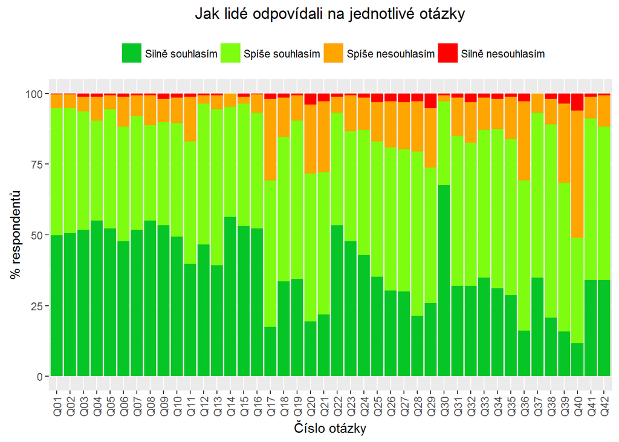

```r
data <- fread("https://raw.githubusercontent.com/KPMG-CZ/R-Data-Challenge/master/Survey_Evaluation/survey_data.csv")
data <- data.frame(data)
#data <- read.csv("C:\\Users\\Michal\\AppData\\Local\\Temp\\RtmpIJahfD\\data1e9475221c7a", sep=";", stringsAsFactors=FALSE)

#naming columns in a reasonable way
name1 <- rep("Q", times=42)
name2 <- c(rep(0, times=9), rep("", times=(42-9)))
name3 <- 1:42
name <- c("ID", paste0(name1, name2, name3))
colnames(data) <- name

#converting values
data[data=="Silně souhlasím"] <- 1
data[data=="Spíše souhlasím"] <- 2
data[data=="Spíše nesouhlasím"] <- 3
data[data=="Silně nesouhlasím"] <- 4

#transforming to numeric vectors
for (i in 2:43)
{data[,i] <- as.numeric(data[,i])}

#preparing for barcharts
question <- rep(paste0(name1, name2, name3), each=247)
answers <- c()
for (i in 2:43) {
  answers <- c(answers, data[, i])
}

QA <- data.frame(cbind(question, answers))
QA$answers <- as.factor(QA$answers)
QA$question <- QA$question

library(ggplot2)
ansPlot <- ggplot()
ansPlot + geom_bar(data=QA, aes(x=question, y=..count../sum(..count..)*4200, fill=answers)) + labs(x="Číslo otázky", y="% respondentů") + theme(legend.position="top", legend.title=element_blank(), axis.text.x = element_text(angle = 90, vjust = 0.5, hjust=1)) + scale_fill_manual(values=c("#05C626", "#7FFD11", "orange", "red"), labels=c("Silně souhlasím", "Spíše souhlasím", "Spíše nesouhlasím", "Silně nesouhlasím")) + ggtitle("Jak lidé odpovídali na jednotlivé otázky")
```

## Otázky s nejlepšími/nejhoršími výsledky

Odpovědi byly rekódovány na numerické hodnoty (Silně souhlasím=1, spíše souhlasím=2, spíše nesouhlasím=3, silně nesouhlasím=4), tak aby s nimi bylo možné dále pracovat. Na základě součtu hodnot jednotlivých proměnných pak můžeme určit otázky, na které respondenti odpovídali nejčastěji záporně a kladně.

```r
soucet <- colSums(data[, 2:43])
nejhorsi <- sort(soucet, decreasing = TRUE)
head(nejhorsi)
```

```
## Q40 Q39 Q36 Q17 Q20 Q21
## 606 542 537 532 526 516
```

```r
nejlepsi<- sort(soucet, decreasing = FALSE)
head(nejlepsi)
```

```
## Q30 Q14 Q15 Q05 Q22 Q02
## 336 367 375 381 382 383
```

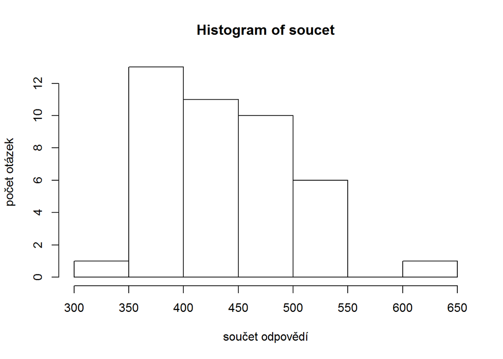

```r
hist(soucet, xlab = "součet odpovědí", ylab="počet otázek")
```

Otázky s nejvíce zápornými odpověďmi byly tyto:

- Q40: Zastávám názor, že naše společnost je příliš shovívavá k zaměstnancům, kteří podávají špatný výkon
- Q39: Jsem přesvědčen(a), že si naše společnost umí udržet schopné a klíčové pracovníky
- Q36: Domnívám se, že týmy/oddělení spolu komunikují dobře a v dostatečné míře
- Q17: Myslím si, že v naší firmě je spolupráce mezi odděleními na dobré úrovni
- Q20: Naše společnost mi nabízí spravedlivou odměnu za odvedenou práci
- Q21: Jsem spokojen(a) s principy a pravidly odměňování

Otázky s nejvíce kladnými odpověďmi:

- Q30: Vím, za co zodpovídám a co se ode mne v práci očekává
- Q14: V našem týmu máme jasně rozdělenou práci
- Q15: Mé oddělení/tým neustále hledá způsoby, jak poskytovat kvalitnější služby svým zákazníkům
- Q05: Důvěřuji rozhodnutím, která učinil můj nadřízený
- Q22: Práce, kterou vykonávám, mě baví a přináší mi uspokojení
- Q02: Můj nadřízený dobře stanovuje cíle a priority

### Histogram součtu hodnot

Po rekódování odpovědí na numerické hodnoty (Silně souhlasím=1, spíše souhlasím=2, spíše nesouhlasím=3, silně nesouhlasím=4), můžeme zjistit, jak lidé odpovídají - tzn. jestli existují tací, kdo souhlasí/nesouhlasí s každou otázkou nebo počet souhlasných a nesouhlasných odpovědí je +/- rovnoměrně distribuován.

Jedinec, který by na každou otázku odpověděl “silně souhlasím” by pak dosáhnul součtu 42.

Jedinec, který by na každou otázku odpověděl “silně nesouhlasím” by pak dosáhnul součtu 168 (42*4).

```r
#sum of responses
sumScore <- c()
for (i in 1:247) {
  suma <- sum(data[i, 2:43])
  sumScore <- c(sumScore, suma)
}
data$sumScore <- sumScore
summary(data$sumScore)
```

```
##    Min. 1st Qu.  Median    Mean 3rd Qu.    Max.
##   42.00   63.00   74.00   74.66   85.00  150.00
```

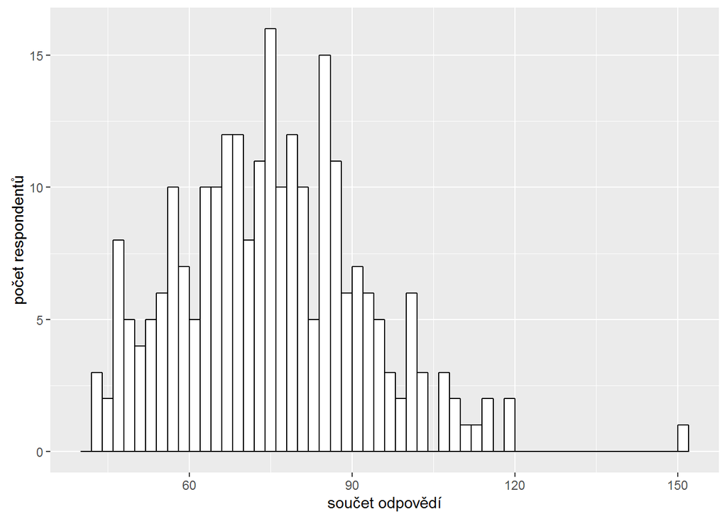

```r
#histogram
histSum <- ggplot(data=data, aes(sumScore))
histSum + geom_histogram(binwidth = 2, colour="black", fill="white") + labs(x="součet odpovědí", y="počet respondentů")
```

### Kolik lidí mělo dotazník v paži (~ odpovídalo stále stejně)

```r
#slackers
min(data$sumScore)
```

```
## [1] 42
```

```r
max(data$sumScore)
```

```
## [1] 150
```

```r
length(data$sumScore[data$sumScore==42])
```

```
## [1] 3
```

```r
length(data$sumScore[data$sumScore==42*2])
```

```
## [1] 5
```

```r
slackers <- data[data$sumScore == 84,]
slackers <- slackers[, 2:43]==2
slackers[slackers==FALSE] <- NA
slackers <- slackers[complete.cases(slackers), ]
nrow(slackers)
```

```
## [1] 2
```

```r
length(data$sumScore[data$sumScore==42*3])
```

```
## [1] 0
```

V celém datasetu se vyskytují 3 lidé, kteří vždy odpovídali “silně souhlasím”, což nevypovídá o jejich spokojenosti, ale spíše o nedostatku zainteresovanosti do vyplňování dotazníku (Lidé, kteří odpovídají stejně, patrně nevěnují otázkám příliš pozornosti, ale spíše vyplňují dotazník, aby to měli zkrku). O tom svědčí i jejich odpovědi na otázku Q40, ve které na rozdíl od všech ostatních otázek souhlas znamená existenci negativního jevu ve firmě. Zároveň se v datasetu vyskytují další 2 lidé, kteří na všechny otázky odpověděli “spíše souhlasím”. Což dává celkem 5 lidí, u kterých existuje pravděpodobnost, že odpovídání na dotazník měli “na háku”.

## Korelace

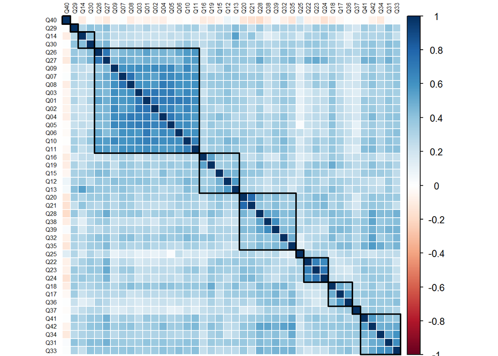

```r
#creating corrplot
library(corrplot)
kor_matrix <- cor(data[, 2:43], method="spearman")
corrplot(kor_matrix, method="color", order="hclust", addrect=11, tl.cex=0.5, tl.col="black")
```

Z corrplotu je vidět, že některé proměnné spolu korelují více než jiné. Konkrétně můžeme vidět několik skupin:

- Q01-Q11 a Q26-7, které hodnotí spokojenost s výkonem nadřízeného + poskytování zpětné vazby
- Q20-21, Q28, Q38-39, Q32, Q35, které hodnotí vnitřní fungování firmy (principy odměňování, přijímání nových zaměstnanců, možnost vyjádřit své názory)
- Q12-3, Q15-6, Q19 - fungování týmu/oddělení
- Q31, Q33-34, Q41-42, které hodnotí informovanost a prostředí ve firmě
- Q22-24 - spokojenost s vykonávanou prací
- Q14, Q30 - rozdělení zodpovědnosti
- Q29 - hodnocení školení
- Q25 - sladění osobního a pracovního života
- Q40 - benevolence k neschopným zaměstnancům
- Q37 - používané nástroje k informování zaměstnanců

```r
sumCluster1 <- c()
for (i in 1:247) {
  suma1 <- sum(data[i, c(2:12, 27:28)])
  sumCluster1 <- c(sumCluster1, suma1)
}
data$sumCluster1 <- sumCluster1


sumCluster2 <- c()
for (i in 1:247) {
  suma2 <- sum(data[i, c(21, 22, 29, 39, 40, 33, 36)])
  sumCluster2 <- c(sumCluster2, suma2)
}
data$sumCluster2 <- sumCluster2

sumCluster3 <- c()
for (i in 1:247) {
  suma3 <- sum(data[i, c(13, 14, 16, 17, 20)])
  sumCluster3 <- c(sumCluster3, suma3)
}
data$sumCluster3 <- sumCluster3

sumCluster4 <- c()
for (i in 1:247) {
  suma4 <- sum(data[i, c(42, 43, 35, 32, 34)])
  sumCluster4 <- c(sumCluster4, suma4)
}
data$sumCluster4 <- sumCluster4
```

### Grafy ukazující souvislost mezi vybranými skupinami proměnných (vycházejících z grafu korelací)

- sumCluster1: spokojenost s nadřízeným
- sumCluster2: vnitřní fungování firmy
- sumCluster3: fungování týmu/oddělení
- sumCluster4: prostředí ve firmě

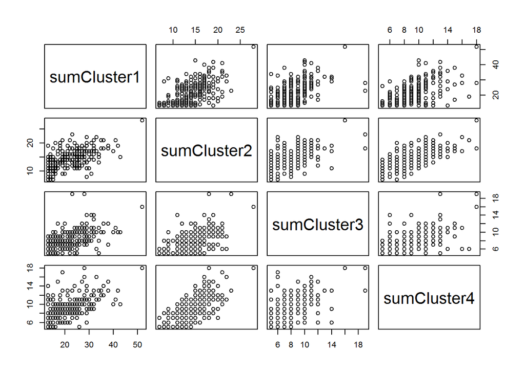

```r
plot(data[, 45:48])
```

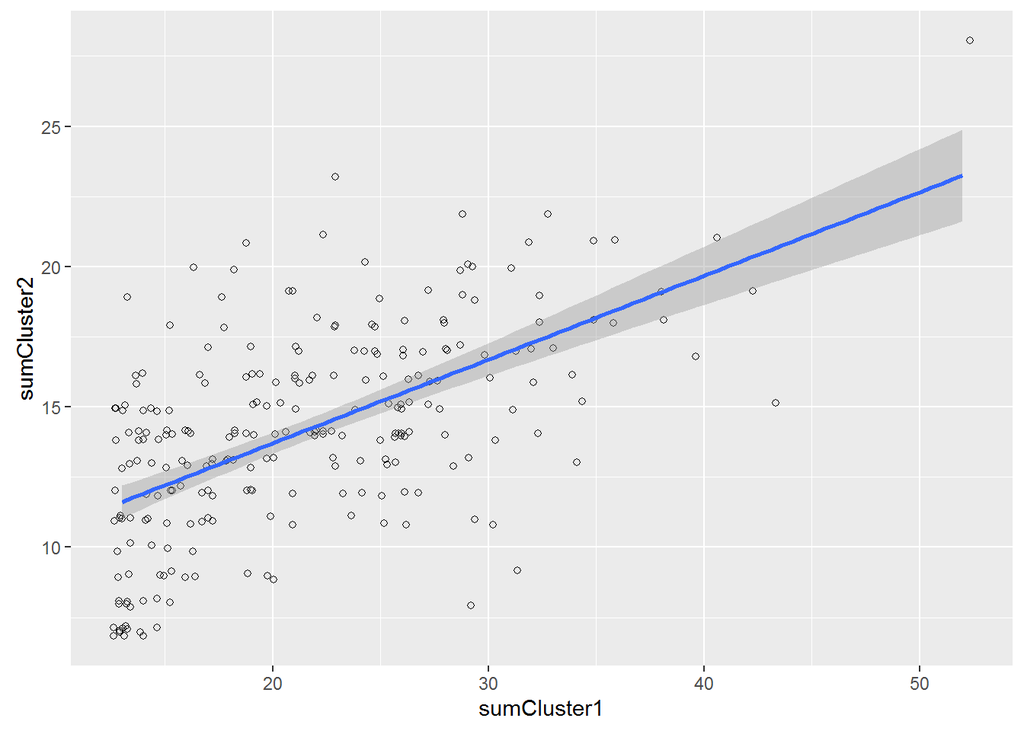

```r
ggplot(data=data, aes(x=sumCluster1, y=sumCluster2)) + geom_point(shape=1, position=position_jitter(width=1,height=.5)) + geom_smooth(method=lm)
```

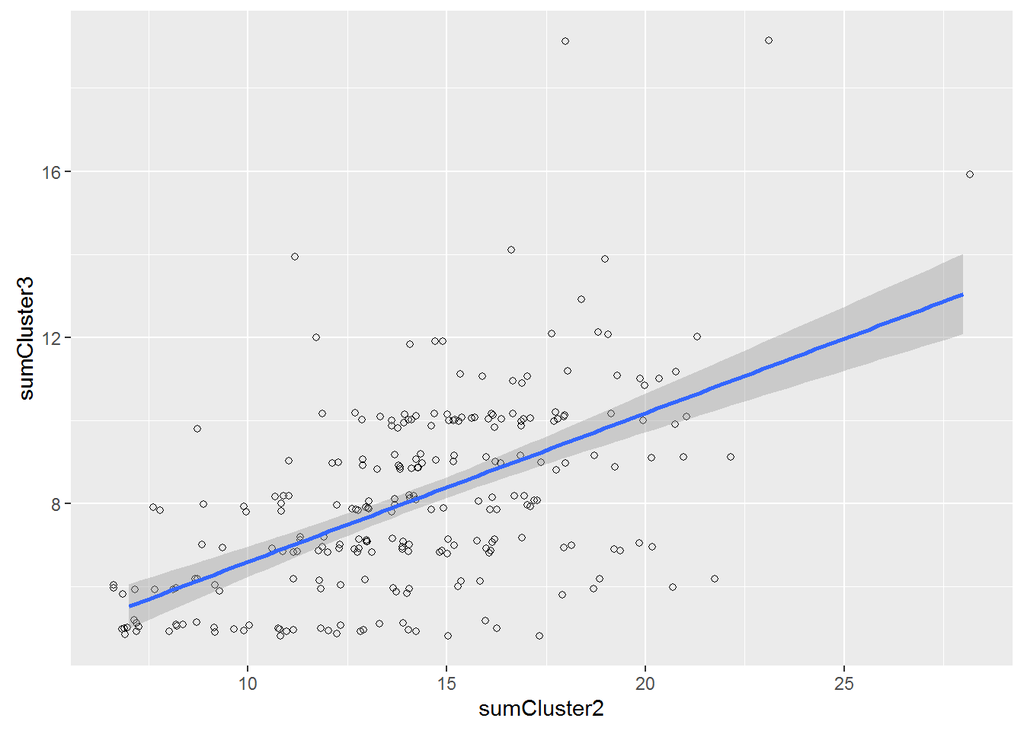

```r
ggplot(data=data, aes(x=sumCluster2, y=sumCluster3)) + geom_point(shape=1, position=position_jitter(width=1,height=.5)) + geom_smooth(method=lm)
```

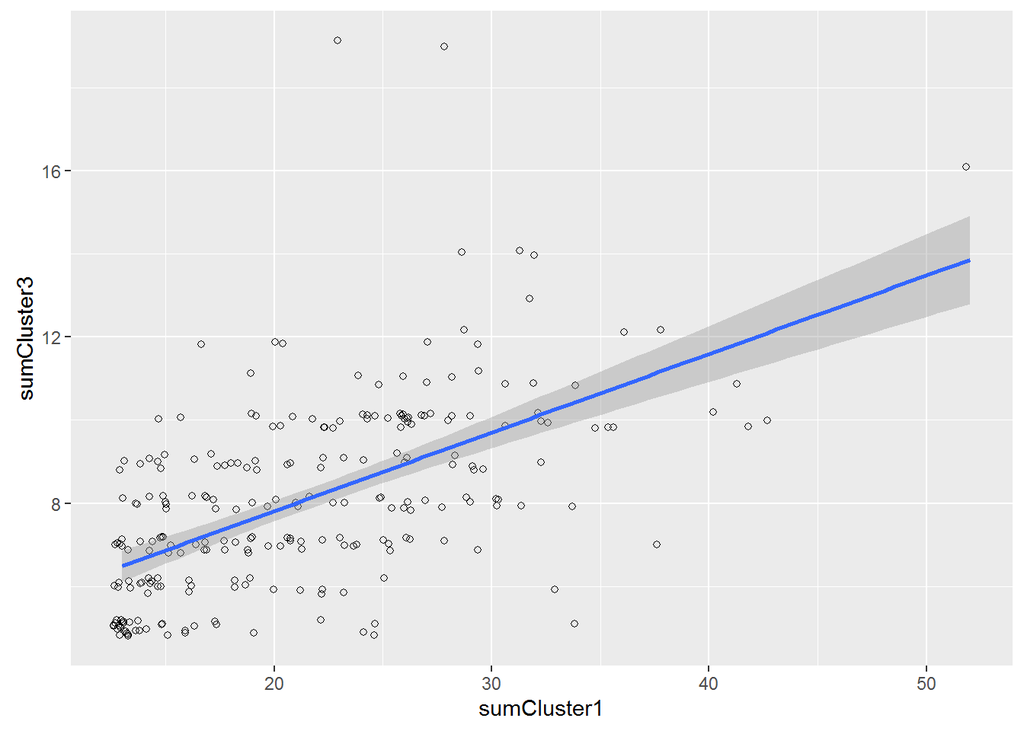

```r
ggplot(data=data, aes(x=sumCluster1, y=sumCluster3)) + geom_point(shape=1, position=position_jitter(width=1,height=.5)) + geom_smooth(method=lm)
```

### Hierarchické clusterování

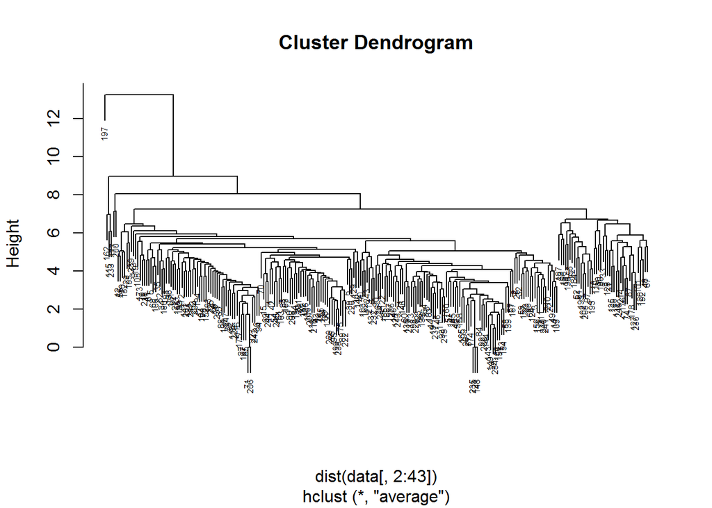

```r
#hierarchical clustering
clusters <- hclust(dist(data[, 2:43]), method="average")
plot(clusters, cex=0.5)
```

## PCA

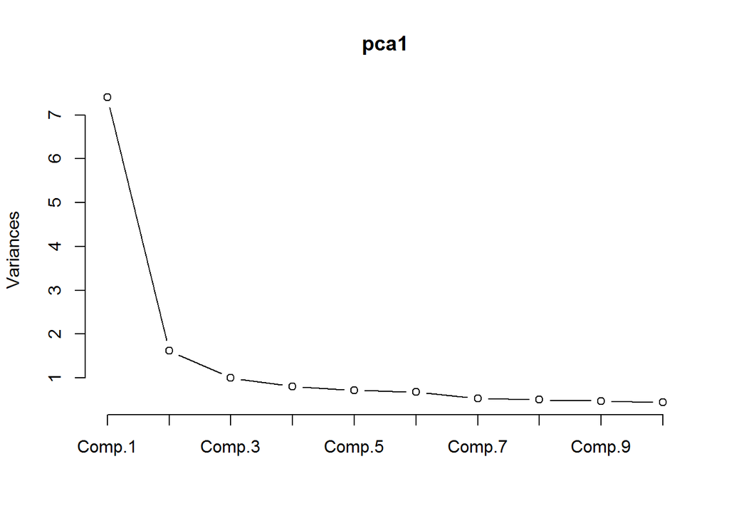

```r
#Principal component analysis
pca1 <- princomp(data[, 2:43], scores = TRUE, cor = FALSE)

#barvy pro +/- kvartily podle souctu hodnot odpovedi
data$groups <- c()
for (i in 1:247) {
  if (data$sumScore[i] < 63) {data$groups[i] <- "#05C626"}
  if (data$sumScore[i] >= 63 && data$sumScore[i] < 74) {data$groups[i] <- "#7FFD11"}
  if (data$sumScore[i] >= 74 && data$sumScore[i] < 86) {data$groups[i] <- "orange"}
  if (data$sumScore[i] >= 86) {data$groups[i] <- "red"}
}

screeplot(pca1, type="l")
```

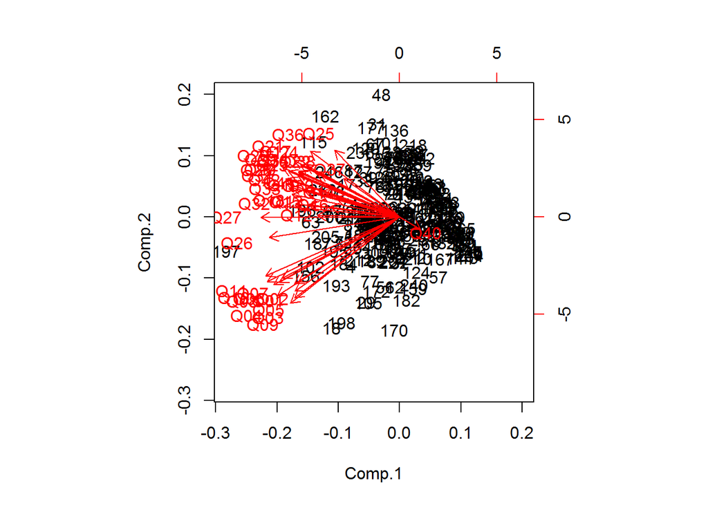

```r
biplot(pca1)
```

```r
summary(pca1)
```

```
## Importance of components:
##                           Comp.1     Comp.2     Comp.3     Comp.4
## Standard deviation     2.7204231 1.27302125 0.99918939 0.89448825
## Proportion of Variance 0.3701237 0.08104855 0.04993092 0.04001504
## Cumulative Proportion  0.3701237 0.45117220 0.50110313 0.54111816
##                            Comp.5     Comp.6     Comp.7     Comp.8
## Standard deviation     0.84660634 0.81947344 0.72885123 0.70928592
## Proportion of Variance 0.03584569 0.03358487 0.02656756 0.02516035
## Cumulative Proportion  0.57696386 0.61054873 0.63711629 0.66227664
##                            Comp.9    Comp.10    Comp.11    Comp.12
## Standard deviation     0.68329155 0.66257653 0.64107665 0.61308353
## Proportion of Variance 0.02334995 0.02195564 0.02055388 0.01879807
## Cumulative Proportion  0.68562660 0.70758223 0.72813611 0.74693418
##                           Comp.13    Comp.14    Comp.15    Comp.16
## Standard deviation     0.58074076 0.54732578 0.53396180 0.52950236
## Proportion of Variance 0.01686703 0.01498186 0.01425917 0.01402199
## Cumulative Proportion  0.76380121 0.77878307 0.79304224 0.80706424
##                           Comp.17    Comp.18    Comp.19    Comp.20
## Standard deviation     0.51712332 0.50197263 0.48854524 0.48090691
## Proportion of Variance 0.01337403 0.01260184 0.01193668 0.01156634
## Cumulative Proportion  0.82043826 0.83304011 0.84497679 0.85654313
##                           Comp.21    Comp.22    Comp.23     Comp.24
## Standard deviation     0.46506671 0.45818163 0.45090928 0.431816056
## Proportion of Variance 0.01081694 0.01049903 0.01016839 0.009325487
## Cumulative Proportion  0.86736007 0.87785910 0.88802749 0.897352980
##                           Comp.25     Comp.26     Comp.27     Comp.28
## Standard deviation     0.41708124 0.410990901 0.401985183 0.400644969
## Proportion of Variance 0.00869992 0.008447698 0.008081538 0.008027741
## Cumulative Proportion  0.90605290 0.914500597 0.922582136 0.930609876
##                            Comp.29     Comp.30     Comp.31     Comp.32
## Standard deviation     0.380472644 0.371759778 0.352350383 0.339866025
## Proportion of Variance 0.007239704 0.006911921 0.006209025 0.005776828
## Cumulative Proportion  0.937849581 0.944761501 0.950970527 0.956747355
##                            Comp.33     Comp.34     Comp.35     Comp.36
## Standard deviation     0.328590712 0.327044418 0.318043531 0.307252078
## Proportion of Variance 0.005399885 0.005349183 0.005058795 0.004721322
## Cumulative Proportion  0.962147240 0.967496423 0.972555218 0.977276539
##                            Comp.37    Comp.38     Comp.39     Comp.40
## Standard deviation     0.304250550 0.29741055 0.281637184 0.273154870
## Proportion of Variance 0.004629528 0.00442371 0.003966925 0.003731572
## Cumulative Proportion  0.981906067 0.98632978 0.990296702 0.994028274
##                           Comp.41     Comp.42
## Standard deviation     0.25874886 0.229030477
## Proportion of Variance 0.00334835 0.002623376
## Cumulative Proportion  0.99737662 1.000000000
```

```r
pca1$loadings
```

```
##
## Loadings:
##     Comp.1 Comp.2 Comp.3 Comp.4 Comp.5 Comp.6 Comp.7 Comp.8 Comp.9 Comp.10
## Q01 -0.158 -0.215
## Q02 -0.152 -0.210
## Q03 -0.158 -0.260
## Q04 -0.184 -0.254                              0.107        -0.110
## Q05 -0.157 -0.239
## Q06 -0.180 -0.210                      -0.182                       0.110
## Q07 -0.176 -0.197
## Q08 -0.189 -0.218                                                  -0.123
## Q09 -0.164 -0.276                                     0.117        -0.192
## Q10 -0.199 -0.208                                            0.118
## Q11 -0.201 -0.190                                    -0.148  0.107
## Q12 -0.124                0.161  0.254                              0.109
## Q13 -0.134        -0.113  0.188  0.294                0.198
## Q14               -0.128         0.134        -0.106  0.279         0.206
## Q15 -0.137                       0.150                0.165         0.113
## Q16 -0.104                       0.409         0.257  0.113
## Q17 -0.149  0.168  0.236         0.219               -0.107
## Q18 -0.156         0.144         0.370               -0.233  0.142
## Q19 -0.139                       0.293         0.222
## Q20 -0.176  0.158 -0.116 -0.210        -0.438 -0.211  0.166
## Q21 -0.158  0.181 -0.114 -0.293        -0.444 -0.145  0.177         0.256
## Q22 -0.125  0.143 -0.316                       0.287         0.101
## Q23 -0.153  0.133 -0.388        -0.130  0.113  0.261         0.188 -0.156
## Q24 -0.140  0.166 -0.351 -0.161 -0.154         0.247               -0.117
## Q25         0.214 -0.168  0.288 -0.115 -0.312        -0.424 -0.455
## Q26 -0.195        -0.120  0.117         0.263 -0.238 -0.233 -0.127  0.351
## Q27 -0.208        -0.197                0.281 -0.169 -0.224         0.152
## Q28 -0.171  0.121        -0.162                      -0.101        -0.257
## Q29 -0.168  0.123 -0.156  0.252  0.198        -0.526         0.199 -0.517
## Q30 -0.121                0.131               -0.144  0.141
## Q31 -0.170  0.107         0.188 -0.112                0.236 -0.147 -0.141
## Q32 -0.174         0.179 -0.133                      -0.127  0.264  0.254
## Q33 -0.161         0.245  0.137 -0.191                0.209 -0.266 -0.135
## Q34 -0.151  0.147  0.120        -0.193  0.129         0.310 -0.269 -0.115
## Q35 -0.152  0.143  0.193 -0.105         0.201                0.109  0.129
## Q36 -0.134  0.211  0.287  0.103                0.214 -0.202 -0.132  0.138
## Q37         0.123                       0.156  0.181
```

[output cut: 187 more lines]

```
## SS loadings      1.000   1.000   1.000   1.000   1.000   1.000   1.000
## Proportion Var   0.024   0.024   0.024   0.024   0.024   0.024   0.024
## Cumulative Var   0.381   0.405   0.429   0.452   0.476   0.500   0.524
##                Comp.23 Comp.24 Comp.25 Comp.26 Comp.27 Comp.28 Comp.29
## SS loadings      1.000   1.000   1.000   1.000   1.000   1.000   1.000
## Proportion Var   0.024   0.024   0.024   0.024   0.024   0.024   0.024
## Cumulative Var   0.548   0.571   0.595   0.619   0.643   0.667   0.690
##                Comp.30 Comp.31 Comp.32 Comp.33 Comp.34 Comp.35 Comp.36
## SS loadings      1.000   1.000   1.000   1.000   1.000   1.000   1.000
## Proportion Var   0.024   0.024   0.024   0.024   0.024   0.024   0.024
## Cumulative Var   0.714   0.738   0.762   0.786   0.810   0.833   0.857
##                Comp.37 Comp.38 Comp.39 Comp.40 Comp.41 Comp.42
## SS loadings      1.000   1.000   1.000   1.000   1.000   1.000
## Proportion Var   0.024   0.024   0.024   0.024   0.024   0.024
## Cumulative Var   0.881   0.905   0.929   0.952   0.976   1.000
```

```r
library(rgl)
```

```r
plot3d(pca1$scores[, c(1:3)], col=data$groups)
```

Graf PCA ukazuje první komponent, který vysvětluje nejvíc variace a který zachycuje celkovou “spokojenost” pracovníků. Ostatní komponenty nemají substantivní význam.